# lab7

LAB 7 Priya Inampudi

```python
%echo
import numpy as np
import pandas as pd
from sklearn.model_selection import train_test_split, GridSearchCV, StratifiedKFold, cross_val_score
from sklearn.preprocessing import StandardScaler, label_binarize
from sklearn.neighbors import KNeighborsClassifier
from sklearn.linear_model import LogisticRegression
from sklearn.tree import DecisionTreeClassifier
from sklearn.metrics import confusion_matrix, accuracy_score, classification_report, roc_auc_score, roc_curve, make_scorer, precision_score, recall_score, f1_score, cohen_kappa_score
from sklearn.pipeline import Pipeline
import matplotlib.pyplot as plt
```

```
ECHO is on.
```

**PART 1**

```python
ha = pd.read_csv("https://www.dropbox.com/s/aohbr6yb9ifmc8w/heart_attack.csv?dl=1")

y = ha['output'].astype(int)
X = ha.drop(columns=['output'])
```

```python
X_train, X_test, y_train, y_test = train_test_split(
    X, y, test_size=0.25, random_state=42, stratify=y
)

cv = StratifiedKFold(n_splits=5, shuffle=True, random_state=42)
```

Q1: KNN

```python
knn_pipe = Pipeline([
    ("standardize", StandardScaler()),
    ("knn", KNeighborsClassifier())
])

knn_param_grid = {
    "knn__n_neighbors": list(range(1, 41)),
    "knn__weights": ["uniform", "distance"]
}

knn_search = GridSearchCV(knn_pipe, knn_param_grid, scoring="roc_auc", cv=cv, n_jobs=-1)

knn_fitted = knn_search.fit(X_train, y_train)

knn_best = knn_fitted.best_estimator_
knn_cv_auc = knn_fitted.best_score_
print("KNN best model:", knn_fitted.best_params_)
print("KNN CV AUC:", knn_cv_auc)

y_pred_knn = knn_best.predict(X_test)
y_proba_knn = knn_best.predict_proba(X_test)[:,1]
```

```
KNN best model: {'knn__n_neighbors': 13, 'knn__weights': 'uniform'}
KNN CV AUC: 0.8874231032125769
```

KNN confusion matrix

```python
pd.DataFrame(confusion_matrix(y_test, y_pred_knn), index=["Actual 0","Actual 1"], columns=["Pred 0","Pred 1"])
```

|  | Pred 0 | Pred 1 |
| --- | --- | --- |
| Actual 0 | 14 | 18 |
| Actual 1 | 13 | 24 |

Q2: logistic regression

```python
logreg_pipe = Pipeline([
    ("standardize", StandardScaler()),
    ("logreg", LogisticRegression(max_iter=1000, solver="liblinear"))
])

logreg_param_grid = {
    "logreg__C": np.logspace(-3, 3, 13),
    "logreg__penalty": ["l2"]
}

logreg_search = GridSearchCV(logreg_pipe, logreg_param_grid, scoring="roc_auc", cv=cv, n_jobs=-1)

logreg_search.fit(X_train, y_train)

logreg_best = logreg_search.best_estimator_
logreg_cv_auc = logreg_search.best_score_
print("LogReg best model:", logreg_search.best_params_)
print("LogReg CV AUC:", logreg_cv_auc)

y_pred_logreg = logreg_best.predict(X_test)

y_proba_logreg = logreg_best.predict_proba(X_test)[:,1]
```

```
LogReg best model: {'logreg__C': np.float64(3.1622776601683795), 'logreg__penalty': 'l2'}
LogReg CV AUC: 0.8670312143996355
```

Logistic regression confusion matric

```python
pd.DataFrame(confusion_matrix(y_test, y_pred_logreg), index=["Actual 0","Actual 1"], columns=["Pred 0","Pred 1"])
```

|  | Pred 0 | Pred 1 |
| --- | --- | --- |
| Actual 0 | 20 | 12 |
| Actual 1 | 5 | 32 |

Q3: Decision Tree

```python
dt = DecisionTreeClassifier(random_state=42)

dt_param_grid = {
    "max_depth": list(range(2, 16)),
    "min_samples_leaf": [1, 2, 5, 10]
}

dt_search = GridSearchCV(dt, dt_param_grid, scoring="roc_auc", cv=cv, n_jobs=-1)

dt_search.fit(X_train, y_train)

dt_best =dt_search.best_estimator_
dt_cv_auc = dt_search.best_score_
print("Decision tree best params:", dt_search.best_params_)
print("Decision tree CV AUC:", dt_cv_auc)

y_pred_dt = dt_best.predict(X_test)
y_proba_dt = dt_best.predict_proba(X_test)[:,1]
```

```
Decision tree best params: {'max_depth': 2, 'min_samples_leaf': 10}
Decision tree CV AUC: 0.7982911825017087
```

decision tree confusion matrix

```python
pd.DataFrame(confusion_matrix(y_test, y_pred_dt), index=["Actual 0","Actual 1"], columns=["Pred 0","Pred 1"])
```

|  | Pred 0 | Pred 1 |
| --- | --- | --- |
| Actual 0 | 24 | 8 |
| Actual 1 | 11 | 26 |

Q4: Interpretation

Top logistic coefficients:

```python
logreg_model = logreg_best.named_steps["logreg"]
coef = pd.Series(logreg_model.coef_[0], index=X.columns).sort_values(key=np.abs, ascending=False)
coef.head(8)
```

```
thalach    1.066057
sex       -0.979079
cp         0.776274
trtbps    -0.277771
age       -0.261089
restecg    0.258896
chol      -0.153161
dtype: float64
```

Top decision tree important features:

```python
imp = pd.Series(dt_best.feature_importances_, index=X.columns).sort_values(ascending=False)
imp.head(8)
```

```
cp         0.716969
thalach    0.283031
age        0.000000
sex        0.000000
trtbps     0.000000
chol       0.000000
restecg    0.000000
dtype: float64
```

Logistic model coefficient interpretation

sex: −0.98 –> Negative means being male or female substantially shifts risk

cp: +0.78 –> Higher chest-pain type increases odds of being at risk.

Smaller coefficients for trtbps, age, restecg, chol suggest minor effects after controlling for others.

Most important predictors: Across all models, chest-pain type (cp) and maximum heart rate achieved (thalach) consistently emerged as the strongest predictors of heart-attack risk. Logistic regression additionally emphasized sex as an important variable.

Q5: ROC curves plot

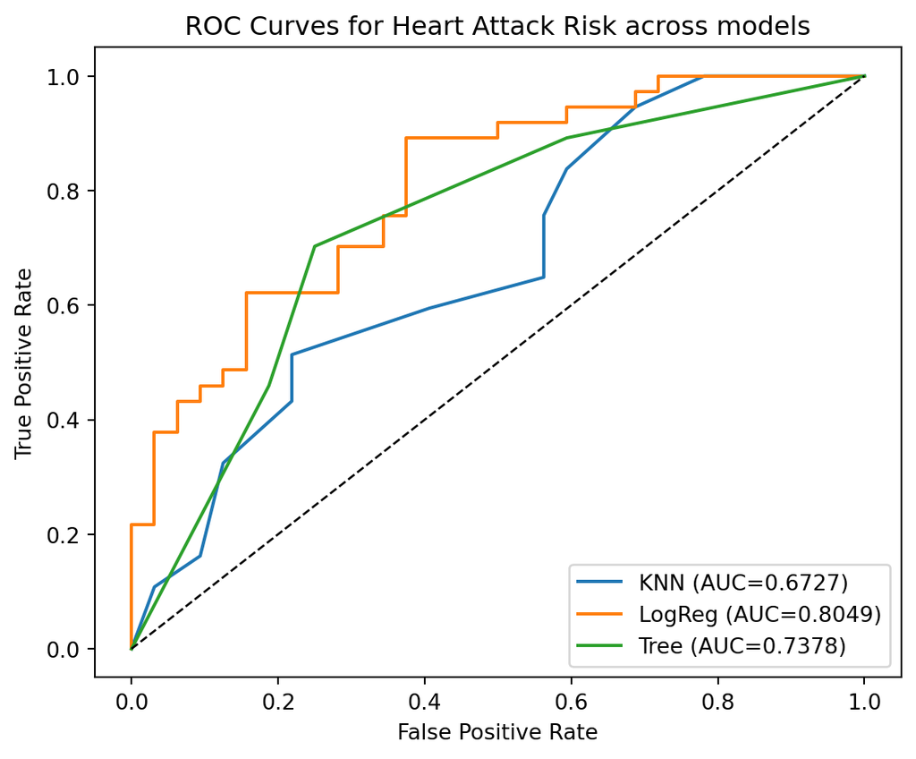

```python
fpr_knn, tpr_knn, thresholds_knn = roc_curve(y_test, y_proba_knn)
fpr_logreg, tpr_logreg, thresholds_logreg = roc_curve(y_test, y_proba_logreg)
fpr_dt, tpr_dt, threshold_dt = roc_curve(y_test, y_proba_dt)

auc_knn  = roc_auc_score(y_test, y_proba_knn)
auc_logreg  = roc_auc_score(y_test, y_proba_logreg)
auc_dt = roc_auc_score(y_test, y_proba_dt)

plt.figure(figsize=(6,5))

plt.plot(fpr_knn,  tpr_knn,  label=f"KNN (AUC={auc_knn:.4f})")

plt.plot(fpr_logreg,  tpr_logreg,  label=f"LogReg (AUC={auc_logreg:.4f})")

plt.plot(fpr_dt, tpr_dt, label=f"Tree (AUC={auc_dt:.4f})")

plt.plot([0,1],[0,1],'k--', linewidth=1)

plt.xlabel("False Positive Rate")
plt.ylabel("True Positive Rate")
plt.title("ROC Curves for Heart Attack Risk across models")
plt.legend()
plt.tight_layout()
plt.show()
```

**PART 2**

```python
tpr_scorer = make_scorer(recall_score)

ppv_scorer = make_scorer(precision_score)

tnr_scorer = make_scorer(recall_score, pos_label=0)

models = {
    "KNN": knn_best,
    "Logistic Regression": logreg_best,
    "Decision Tree": dt_best
}

metrics = []
for name, model in models.items():
    tpr = cross_val_score(model, X, y, cv=cv, scoring=tpr_scorer).mean()
    ppv = cross_val_score(model, X, y, cv=cv, scoring=ppv_scorer).mean()
    tnr = cross_val_score(model, X, y, cv=cv, scoring=tnr_scorer).mean()
    metrics.append({
        "Model": name,
        "True Positive Rate / Recall": tpr,
        "Precision": ppv,
        "True Negative Rate / Specificity": tnr
    })

metrics_df = pd.DataFrame(metrics)
metrics_df.round(4)
```

|  | Model | True Positive Rate / Recall | Precision | True Negative Rate / Specificity |
| --- | --- | --- | --- | --- |
| 0 | KNN | 0.8156 | 0.7514 | 0.6775 |
| 1 | Logistic Regression | 0.8218 | 0.7860 | 0.7403 |
| 2 | Decision Tree | 0.7676 | 0.7745 | 0.7394 |

**PART 3**

Q1: I would aim to maximize recall. For this scenario I’d pick my logistic regression model. With recall being around 0.82, it detects most at-risk patients. Missing even one could be catastrophic, so we want to accept more false positives just for safety.

Q3 (Studying root causes)

Goal: I would use logistic regression so that for each cause I can interpret and understand the coefficients. They’ll show how each factor changes heart-attack odds (e.g. cp, thalach, sex).

Q4 (Training new doctors)

Goal: I would use logistic regression to construct a stable, balanced reference model with good overall accuracy and AUC. For example with a AUC of 0.80 and balanced precision/recall, the model can be a consistent reference point to compare human diagnoses against and evaluating new doctors’ diagnostic skills.

**PART 4**

```python
ha_val = pd.read_csv("https://www.dropbox.com/s/jkwqdiyx6o6oad0/heart_attack_validation.csv?dl=1")
ha_val.head()
```

|  | age | sex | cp | trtbps | chol | restecg | thalach | output |
| --- | --- | --- | --- | --- | --- | --- | --- | --- |
| 0 | 41 | 0 | 1 | 130 | 204 | 0 | 172 | 1 |
| 1 | 64 | 1 | 3 | 110 | 211 | 0 | 144 | 1 |
| 2 | 59 | 1 | 0 | 135 | 234 | 1 | 161 | 1 |
| 3 | 42 | 1 | 0 | 140 | 226 | 1 | 178 | 1 |
| 4 | 40 | 1 | 3 | 140 | 199 | 1 | 178 | 1 |

```python
X_val = ha_val.drop(columns=["output"])
y_val = ha_val["output"].astype(int)
```

```python
models = {
    "KNN": knn_best,
    "Logistic Regression": logreg_best,
    "Decision Tree": dt_best
}

results_val = []
for name, model in models.items():
    y_pred = model.predict(X_val)
    y_proba = model.predict_proba(X_val)[:,1]

    cm = confusion_matrix(y_val, y_pred)
    auc = roc_auc_score(y_val, y_proba)
    prec = precision_score(y_val, y_pred)
    rec = recall_score(y_val, y_pred)

    print("\n", name)
    print("Confusion Matrix:\n", pd.DataFrame(cm, index=["Actual 0","Actual 1"], columns=["Pred 0","Pred 1"]))
    print(f"AUC = {auc:.4f}  Precision = {prec:.4f}  Recall = {rec:.4f}")

    results_val.append({
        "Model": name,
        "AUC": auc,
        "Precision": prec,
        "Recall": rec
    })
```

```
 KNN
Confusion Matrix:
           Pred 0  Pred 1
Actual 0       9       2
Actual 1       4      15
AUC = 0.9330  Precision = 0.8824  Recall = 0.7895

 Logistic Regression
Confusion Matrix:
           Pred 0  Pred 1
Actual 0       9       2
Actual 1       4      15
AUC = 0.8947  Precision = 0.8824  Recall = 0.7895

 Decision Tree
Confusion Matrix:
           Pred 0  Pred 1
Actual 0      10       1
Actual 1       5      14
AUC = 0.8636  Precision = 0.9333  Recall = 0.7368
```

Validation Stats

```python
val_df = pd.DataFrame(results_val)
val_df.round(4)
```

|  | Model | AUC | Precision | Recall |
| --- | --- | --- | --- | --- |
| 0 | KNN | 0.9330 | 0.8824 | 0.7895 |
| 1 | Logistic Regression | 0.8947 | 0.8824 | 0.7895 |
| 2 | Decision Tree | 0.8636 | 0.9333 | 0.7368 |

The validation set confirmed the stability of the three tuned models.

- KNN achieved the highest validation AUC of 0.93, but performed very similarly to the logistic regression in terms of precision: 0.88 and recall: 0.79.
- The decision tree model remained more conservative, yielding the highest precision of 0.93 but a lower recall of 0.74.

**PART 5**

```python
kappa_results = []
for name, model in models.items():
    y_pred = model.predict(X_val)
    kappa = cohen_kappa_score(y_val, y_pred)
    kappa_results.append({"Model": name, "Cohen Kappa": kappa})

kappa_df = pd.DataFrame(kappa_results)
kappa_df.round(4)
```

|  | Model | Cohen Kappa |
| --- | --- | --- |
| 0 | KNN | 0.5853 |
| 1 | Logistic Regression | 0.5853 |
| 2 | Decision Tree | 0.6000 |

Cohen’s Kappa was calculated to assess the agreement between predicted and actual classifications while adjusting for random chance.

All three models demonstrated enough agreement. KNN and logistic regression both achieved a K value of 0.585, while the Decision Tree achieved 0.60.

These results confirm our earlier resultss. Each model provides meaningful predictive ability, but the decision tree’s slightly higher Kappa suggests greater consistency in its predictions. However, this difference is small, and overall, the logistic regression model still remains preferred for its balance of performance, interpretability, and generalization. So the Kappa results do not change our previous conclusions but confirm that all three models are performing well above chance.